# PSI_Capstone Pair Project

Ruei Li Jhang & Chia Hua Lin

2024-03-25

```r
# Loading libraries

library(dplyr)
library(ggplot2)
library(ltm)
library(randomForest)
library(rpart)
library(e1071)
library(mlbench)
library(caTools)
library(caret)
library(pROC)
library(PRROC)
library(ROCR)
library(xgboost)
#library(kableExtra)

#devtools::install_github("kupietz/kableExtra")
```

# Data Understanding

The data set was downloaded from Kaggle.com. According to the data description, the data focuses on malicious URL detection. This data helps in the development of cyber security systems that can detect any malicious attempt to gain access and send a sigal to systems to perform the relevant in return.

Data set link: https://www.kaggle.com/datasets/pilarpieiro/tabular-dataset-ready-for-malicious-url-detection/data

The data set includes URLs and 60 other calculated features. In our analysis, we will not use all the 60 features, but we will select the most important features. In the data description, a list of 6 important features has been provided and they are as follows:

- Basic URL Components
- Domain Information
- Content Analysis
- Host Reputation
- Network Features
- Behavioural Features

```r
# # Loading the train data
# train_data <- read.csv('train_dataset.csv')
# train_data <- na.omit(train_data) # Remove rows with any NA/null values
# dim(train_data)

# # Loading test data
# test_data <- read.csv('test_dataset.csv')
# test_data <- na.omit(test_data) # Remove rows with any NA/null values
# dim(test_data)
```

The original train data has 6,728,848 observations and the test data contains 1,682,213.

```r
# # Set seed for reproducibility
# set.seed(2024)

# # Define the number of samples you want for each label category
# num_samples_per_label <- 1000000

# # Sample from each label category
# train_data_sample <- train_data %>%
#    group_by(label) %>%
#    sample_n(num_samples_per_label, replace = TRUE)

# # Test data
# test_data_sample <- test_data[sample(nrow(test_data), 1000000), ]

# # Write train_data2 to CSV
# write.csv(train_data_sample, file = "train_data_sample.csv", row.names = FALSE)
# write.csv(test_data_sample, file = "test_data_sample.csv", row.names = FALSE)
```

## Loading the Save Data

```r
# Loading the train data
train_data <- read.csv('train_data_sample.csv')
train_data <- na.omit(train_data) # Remove rows with any NA/null values
dim(train_data)
```

```
## [1] 200000     60
```

```r
# Loading the test data
test_data <- read.csv('test_data_sample.csv')
test_data <- na.omit(test_data) # Remove rows with any NA/null values
dim(test_data)
```

```
## [1] 100000     60
```

## Selecting Necessary Columns

We selected specific columns from the train_data data frame. The columns selected include various features related to URLs as:

- Whether the URL contains certain elements like login, client, server, admin, IP,
- Whether it is shortened,
- Its length, entropy,
- Its counts of various characters and components,
- Features related to the length
- Components of the path,
- Query, sub domain, and primary domain of the URL.
- Label column indicating some classification or labeling information associated with each URL.

```r
# Train data
train_data <- train_data %>%
  dplyr::select(url, source, url_has_login, url_has_client, url_has_server,
                url_has_admin, url_has_ip, url_isshorted, url_len,
                url_entropy, url_count_dot, url_count_https, url_count_http,
                url_count_perc, url_count_hyphen, url_count_www,
                url_count_hash, url_count_semicolon, url_count_underscore,
                url_count_ques, url_count_equal, url_count_amp,
                url_count_letter, url_count_digit,
                url_count_sensitive_financial_words,
                url_count_sensitive_words, path_len, query_len,
                query_count_components, pdomain_len, subdomain_len,
                subdomain_count_dot, label
                )
```

## Exploratory Data Analysis

During EDA, we are going to perform tasks such as:

- Summarizing the distribution of each variable (count and distribution)
  - Binary Variables
    - Select 6 columns to identify binary variables.Check if the column is numeric and if it possesses only two unique values. If these conditions were met, then the column contains binary data.
- Visualizing relationships between variables (scatter plots, box plots)
  - Distribution of Numerical Variables
    - We filtered out specific columns that mentioned selected variables and used histograms to analyze their distribution.
- Detecting outliers or anomalies (histograms)
  - Treating Outliers
    - We defined a function for identifying and managing outliers and took three parameters: the dataset data, specifying the vector of columns to process, and determining the threshold for anomaly detection criteria, set to 3 standard deviations from the mean. We replace outliers with missing(NA) and print a summary for each column, indicating the number of outliers. Then we ignore all the missing values(NA).
- Exploring correlations between variables
  - Correlation Between Numerical Variables and Target Variable, Label
  - Correlation Between Binary Variable and Target Variable, Label
- Identifying potential patterns or trends in the data

### Binary Variables

Here, we’re preparing for Exploratory Data Analysis (EDA) by selecting specific columns from the train_data dataframe. We are identifying binary variables within the train_dataset. The criteria involve checking if the column is numeric and if it possesses only two unique values. If these conditions are satisfied, indicating that the column indeed contains binary data, we add it to the binary_vars list.

```r
# Initialize an empty list to store binary variables
binary_vars <- list()

# Loop through each column in the dataset
for (col in names(train_data)) {

  # Check if the column is numeric and has only two unique values
  if (is.numeric(train_data[[col]]) && length(unique(train_data[[col]])) == 2) {

    # If the condition is met, add the column to the list
    binary_vars[[col]] <- train_data[[col]]
  }
}

# Convert the list of binary variables to a dataframe
binary_df <- as.data.frame(binary_vars)

# Convert all columns in binary_df to factors
binary_df <- as.data.frame(lapply(binary_df, as.factor))

# Overview
head(binary_df, 5)
```

|  | url_has_login | url_has_client | url_has_server | url_has_admin | url_has_ip | url_isshorted | label |
| --- | --- | --- | --- | --- | --- | --- | --- |
| 1 | 0 | 0 | 0 | 0 | 0 | 1 | 0 |
| 2 | 0 | 0 | 0 | 0 | 0 | 0 | 0 |
| 3 | 0 | 0 | 0 | 0 | 0 | 0 | 0 |
| 4 | 0 | 0 | 0 | 0 | 0 | 0 | 0 |
| 5 | 0 | 0 | 0 | 0 | 0 | 0 | 0 |

#### Distribution of url_has_login

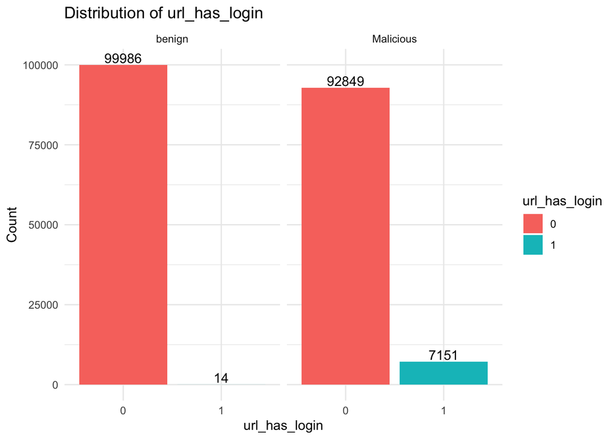

```r
# Plotting the count of url_has_login
ggplot(binary_df, aes(x = url_has_login, fill = url_has_login)) +
  geom_bar(stat = "count", position = "dodge") +
  geom_text(stat = "count", aes(label = after_stat(count)),
            vjust = -0.2, position = position_dodge(width = 0.8)) +
  labs(title = "Distribution of url_has_login",
       x = "url_has_login",
       y = "Count") +
  theme_minimal() +
  facet_wrap(~ label, labeller = labeller(label = c("0" = "benign", "1" = "Malicious")))
```

For the URLs that are not malicious, 99986 had no login while 14 had login. For the malicious URLs, 92849 had nolog in while 7151 had login.

#### Distribution of url_has_client

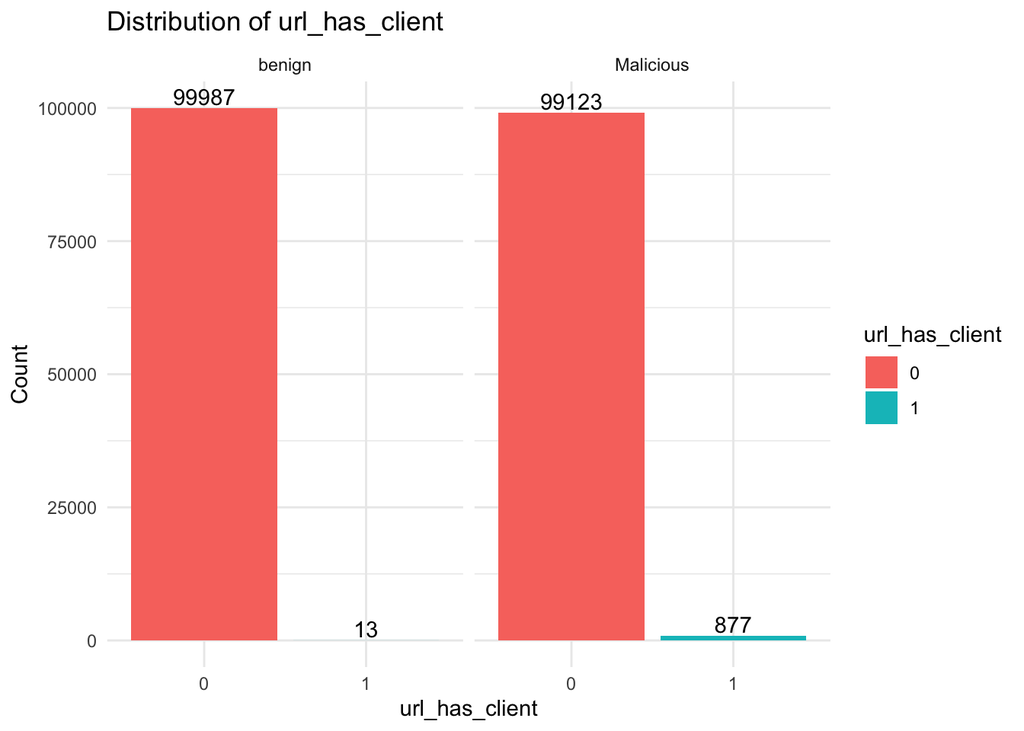

```r
ggplot(binary_df, aes(x = url_has_client, fill = url_has_client)) +
  geom_bar(stat = "count", position = "dodge") +
  geom_text(stat = "count", aes(label = after_stat(count)),
            vjust = -0.2, position = position_dodge(width = 0.8)) +
  labs(title = "Distribution of url_has_client",
       x = "url_has_client",
       y = "Count") +
  theme_minimal() +
  facet_wrap(~ label, labeller = labeller(label = c("0" = "benign", "1" = "Malicious")))
```

For the URLs that are not malicious, 99987 had no clients while 13 had clients. For the malicious URLs, 99123 had no client while 877 had a client.

#### Distribution of url_has_server

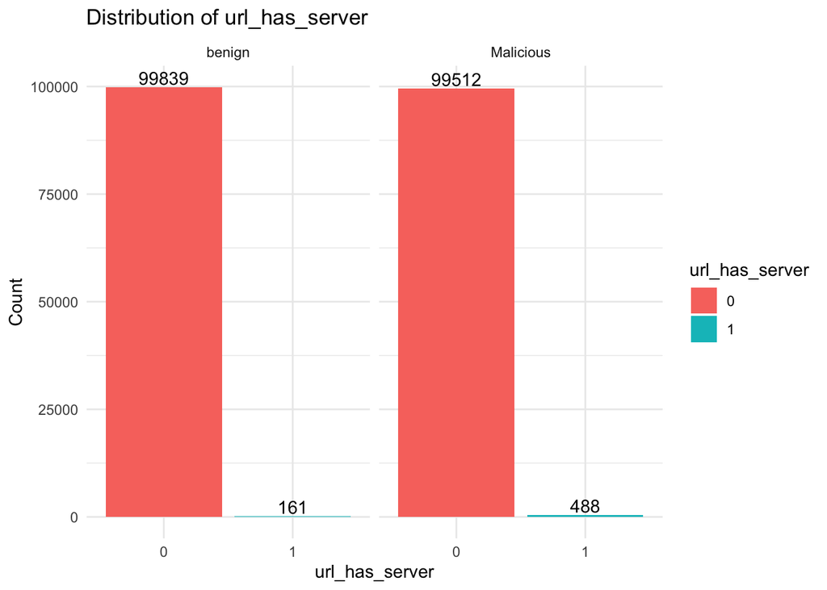

```r
# Plotting the count of url_has_server
ggplot(binary_df, aes(x = url_has_server, fill = url_has_server)) +
  geom_bar(stat = "count", position = "dodge") +
  geom_text(stat = "count", aes(label = after_stat(count)),
            vjust = -0.2, position = position_dodge(width = 0.8)) +
  labs(title = "Distribution of url_has_server",
       x = "url_has_server",
       y = "Count" ) +
  theme_minimal() +
  facet_wrap(~ label, labeller = labeller(label = c ("0" = "benign", "1" = "Malicious")))
```

For the UELs that are not malicious, 99839 had no server while 161 had a server. For the malicious URLs, 99512 had no server while 488 had a server.

#### Distribution of url_has_admin

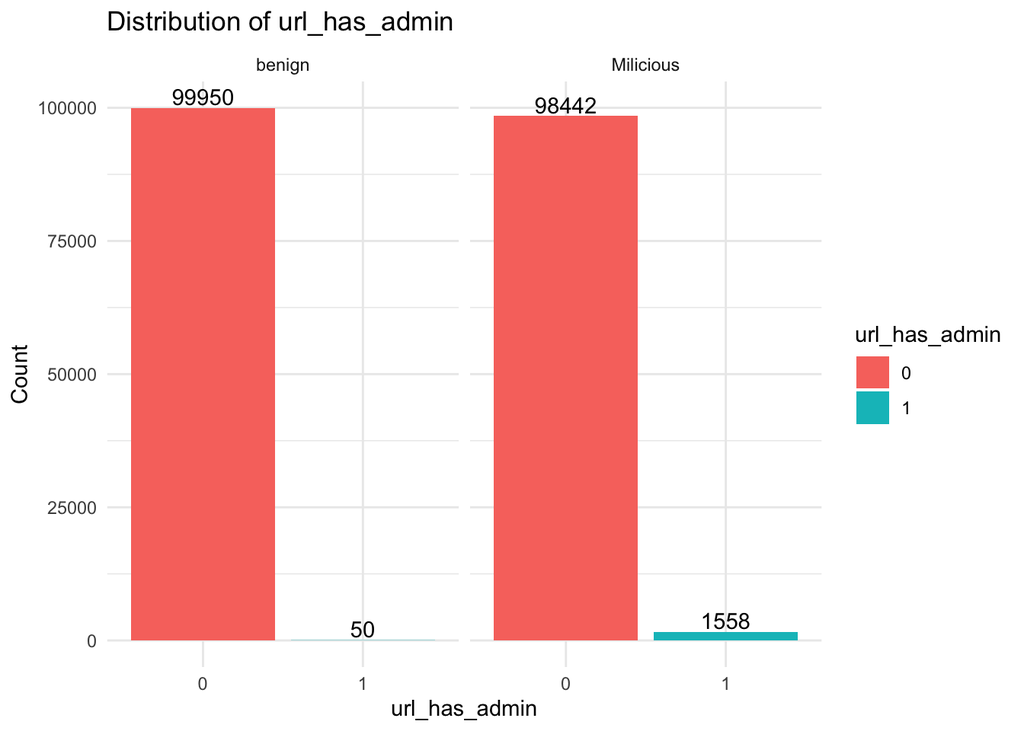

```r
#plotting the count of url_has_admin
ggplot(binary_df, aes(x = url_has_admin, fill = url_has_admin)) +
  geom_bar(stat = "count", position = "dodge") +
  geom_text(stat = "count", aes(label = after_stat(count)),
            vjust = -0.2, position = position_dodge(width = 0.8)) +
  labs(title = "Distribution of url_has_admin",
       x = "url_has_admin",
       y = "Count" ) +
  theme_minimal() +
  facet_wrap(~ label, labeller = labeller(label = c("0" = "benign", "1" = "Milicious")))
```

For the URLs that are not malicious, 99950 had no admin while 50 had admin. For the malicious URLs, 98442 had no admin while 1558 had admin.

#### Distribution of url_has_ip

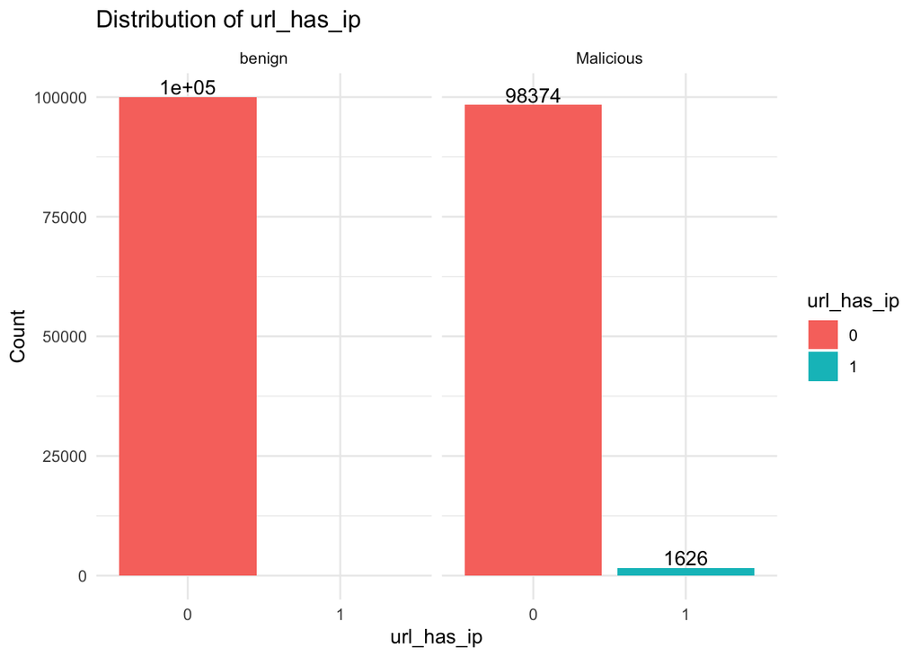

```r
# Plotting the count of url_has_ip
ggplot(binary_df, aes(x = url_has_ip, fill = url_has_ip)) +
  geom_bar(stat = "count", position = "dodge") +
  geom_text(stat = "count", aes(label = after_stat(count)),
            vjust = -0.2, position = position_dodge(width = 0.8)) +
  labs(title = "Distribution of url_has_ip",
       x = "url_has_ip",
       y = "Count" ) +
  theme_minimal() +
  facet_wrap(~ label, labeller = labeller(label = c("0" = "benign", "1" = "Malicious")))
```

For the URLs that are not malicious, all had no IP. For the malicious URLs, 98374 had no IP while 1626 had an IP.

#### Distribution of url_isshorted

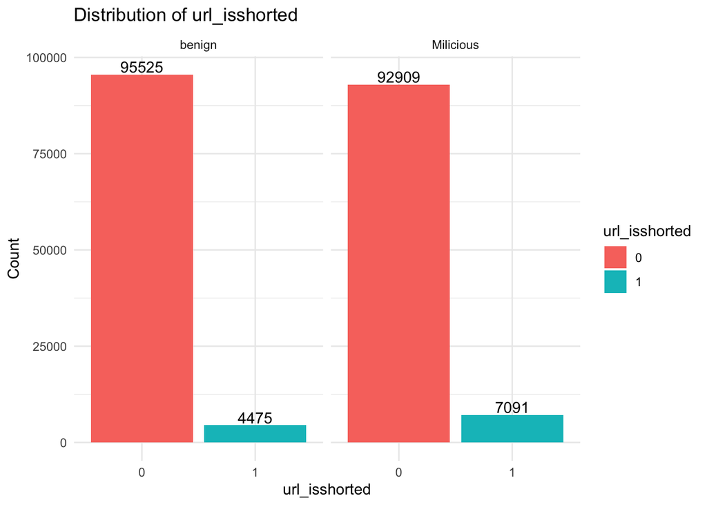

```r
# Plotting the count of url_isshorted
ggplot(binary_df, aes(x = url_isshorted, fill = url_isshorted)) +
  geom_bar(stat = "count", position = "dodge") +
  geom_text(stat = "count", aes(label = after_stat(count)),
            vjust = -0.2, position = position_dodge(width = 0.8)) +
  labs(title = "Distribution of url_isshorted",
       x = "url_isshorted",
       y = "Count" ) +
  theme_minimal() +
  facet_wrap(~ label, labeller = labeller(label = c("0" = "benign", "1" = "Milicious")))
```

For the URLs that are not malicious, 4475 were shortened while 95525 were not. For the malicious URLs, 7091 were shortened while 92909 were not.

#### Distribution of Label

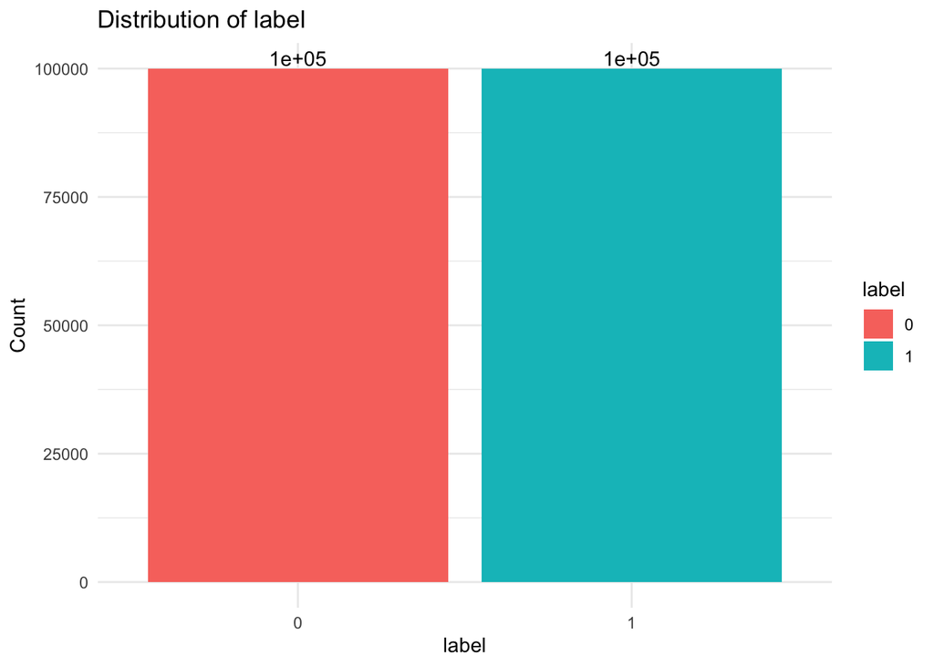

```r
# Plotting the count of label
ggplot(binary_df, aes(x = label, fill = label)) +
  geom_bar(stat = "count", position = "dodge") +
  geom_text(stat = "count", aes(label = after_stat(count)),
            vjust = -0.2, position = position_dodge(width = 0.8)) +
  labs(title = "Distribution of label",
       x = "label",
       y = "Count" ) +
  theme_minimal()
```

Our target variable which is Label, was balanced.

### Distribution of Numerical Variables

```r
# Selecting all columns except the ones mentioned in binary
numerical_columns <- train_data[, !names(train_data) %in% names(binary_df)]

# Remove the first two columns
numerical_columns <- numerical_columns %>%
  dplyr::select(-url, -source)
```

#### Distribution of URL_LEN

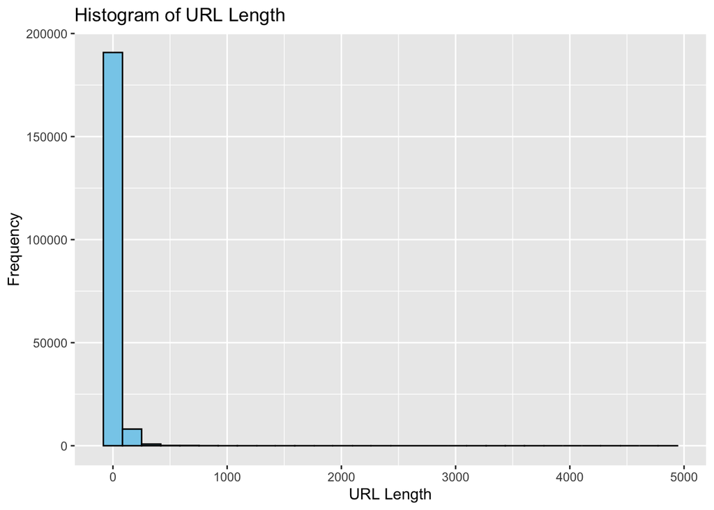

```r
# Plotting histogram using ggplot2
ggplot(numerical_columns, aes(x = url_len)) +
  geom_histogram(bins = 30, fill = "skyblue", color = "black") +
  labs(title = "Histogram of URL Length", x = "URL Length", y = "Frequency")
```

The URL len is positively skewed meaning the majority of the URLs have a shorter length. However, we can already see the presence of outliers in the URL length column. We will treat this by dropping all the outliers.

#### Distribution of url_entropy

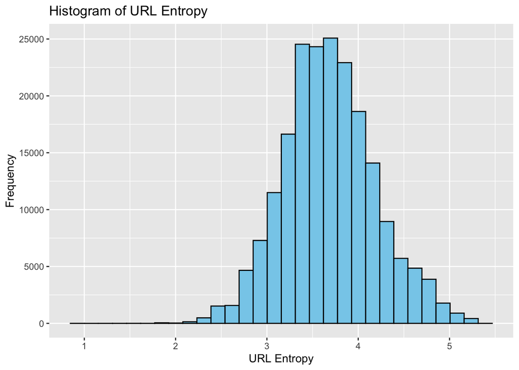

```r
# Plotting histogram using ggplot2
ggplot(numerical_columns, aes(x = url_entropy)) +
  geom_histogram(bins = 30, fill = "skyblue", color = "black") +
  labs(title = "Histogram of URL Entropy", x = "URL Entropy", y = "Frequency")
```

#### Distribution of url_count_dot

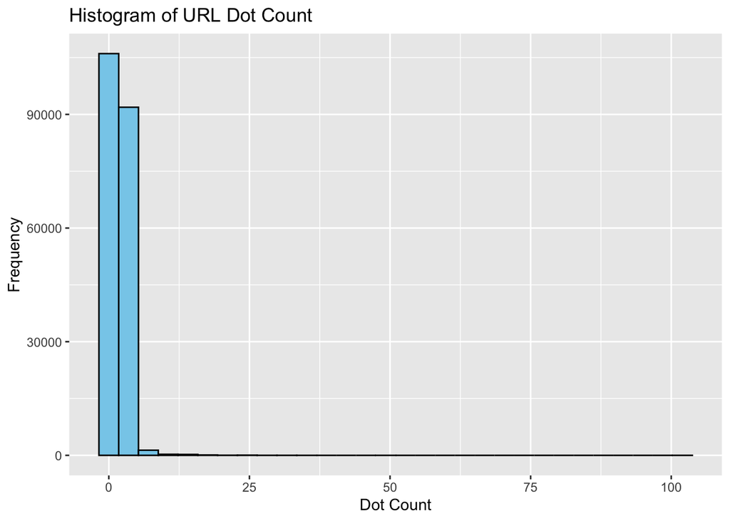

```r
# Plotting histogram using ggplot2
ggplot(numerical_columns, aes(x = url_count_dot)) +
  geom_histogram(bins = 30, fill = "skyblue", color = "black") +
  labs(title = "Histogram of URL Dot Count", x = "Dot Count", y = "Frequency")
```

#### Distribution of url_count_https

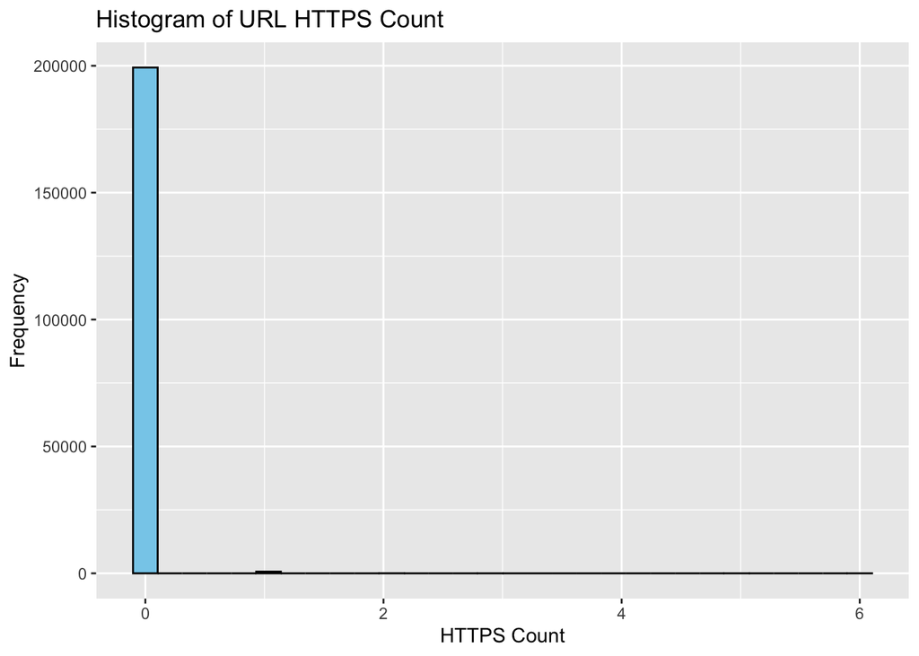

```r
# Plotting histogram using ggplot2
ggplot(numerical_columns, aes(x = url_count_https)) +
  geom_histogram(bins = 30, fill = "skyblue", color = "black") +
  labs(title = "Histogram of URL HTTPS Count", x = "HTTPS Count", y = "Frequency")
```

#### Distribution of url_count_http

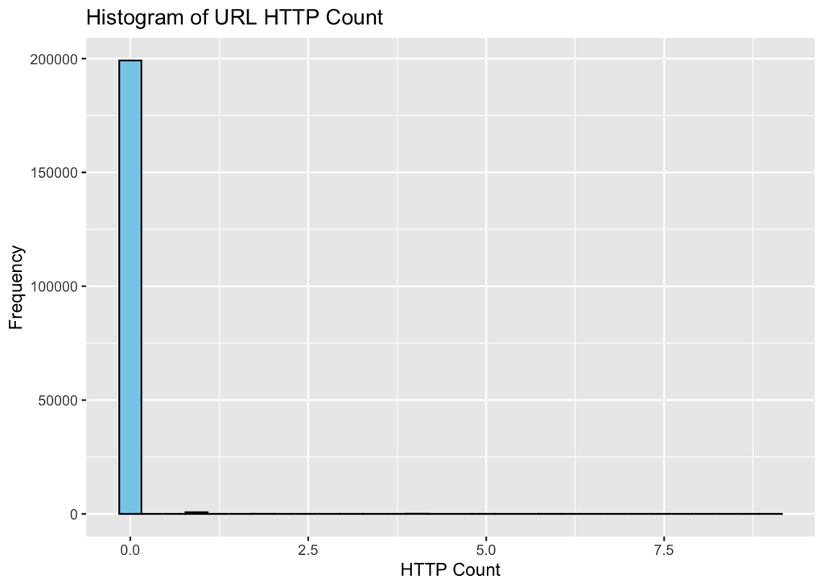

```r
# Plotting histogram using ggplot2
ggplot(numerical_columns, aes(x = url_count_http)) +
  geom_histogram(bins = 30, fill = "skyblue", color = "black") +
  labs(title = "Histogram of URL HTTP Count", x = "HTTP Count", y = "Frequency")
```

#### Distribution of url_count_perc

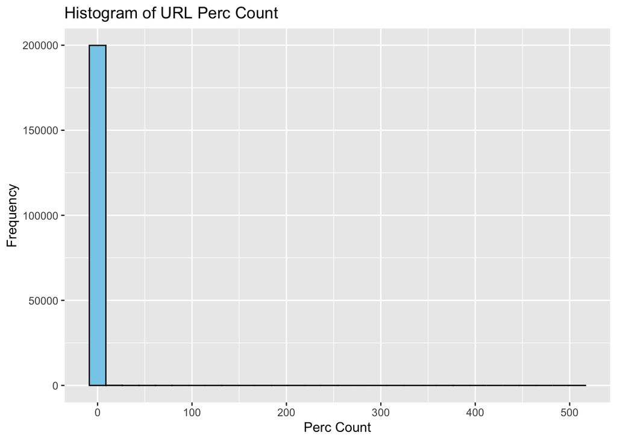

```r
# Plotting histogram using ggplot2
ggplot(numerical_columns, aes(x = url_count_perc)) +
  geom_histogram(bins = 30, fill = "skyblue", color = "black") +
  labs(title = "Histogram of URL Perc Count", x = "Perc Count", y = "Frequency")
```

#### Distribution of url_count_hyphen

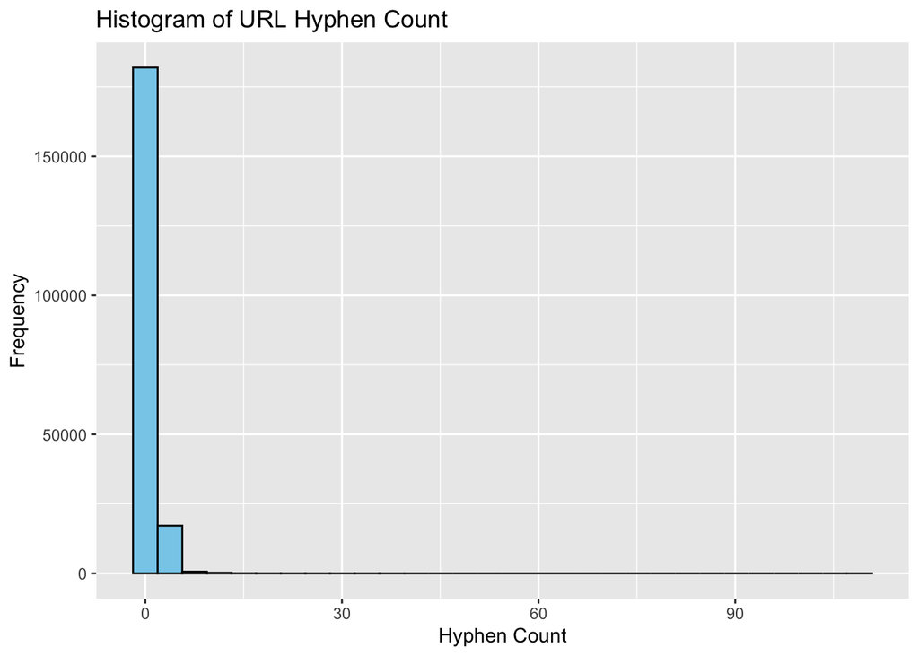

```r
# Plotting histogram using ggplot2
ggplot(numerical_columns, aes(x = url_count_hyphen)) +
  geom_histogram(bins = 30, fill = "skyblue", color = "black") +
  labs(title = "Histogram of URL Hyphen Count", x = "Hyphen Count", y = "Frequency")
```

#### Distribution of url_count_www

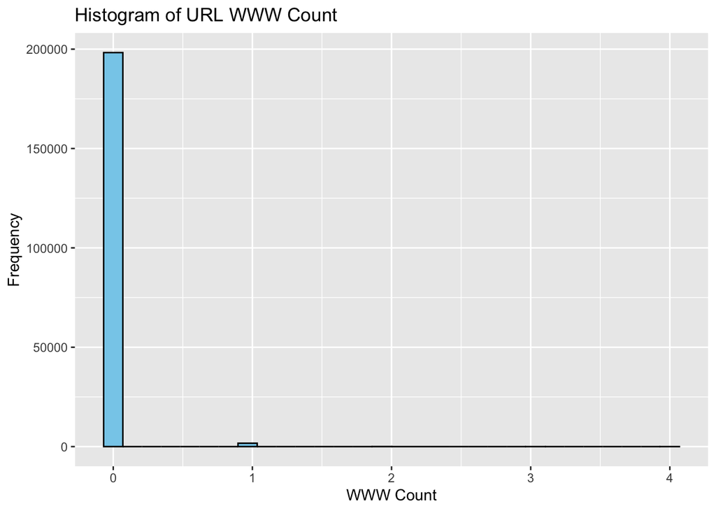

```r
# Plotting histogram using ggplot2
ggplot(numerical_columns, aes(x = url_count_www)) +
  geom_histogram(bins = 30, fill = "skyblue", color = "black") +
  labs(title = "Histogram of URL WWW Count", x = "WWW Count", y = "Frequency")
```

#### Distribution of url_count_hash

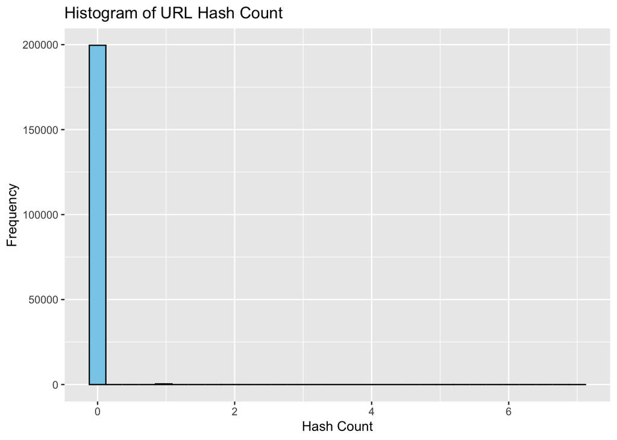

```r
# Plotting histogram using ggplot2
ggplot(numerical_columns, aes(x = url_count_hash)) +
  geom_histogram(bins = 30, fill = "skyblue", color = "black") +
  labs(title = "Histogram of URL Hash Count", x = "Hash Count", y = "Frequency")
```

#### Distribution of url_count_semicolon

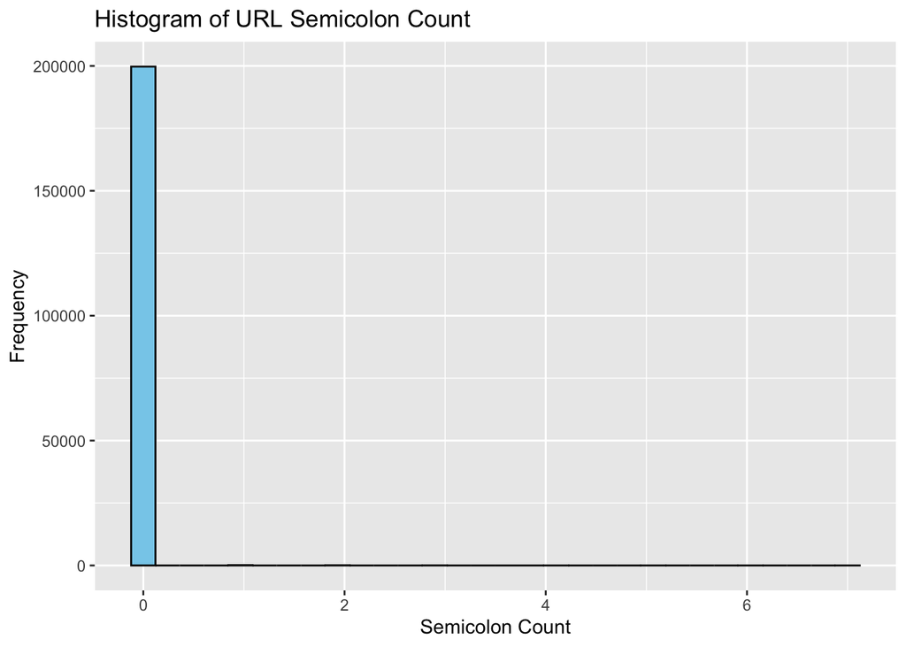

```r
# Plotting histogram using ggplot2
ggplot(numerical_columns, aes(x = url_count_semicolon)) +
  geom_histogram(bins = 30, fill = "skyblue", color = "black") +
  labs(title = "Histogram of URL Semicolon Count", x = "Semicolon Count", y = "Frequency")
```

#### Distribution of url_count_underscore

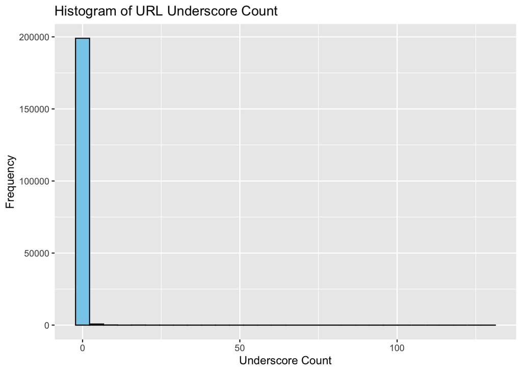

```r
# Plotting histogram using ggplot2
ggplot(numerical_columns, aes(x = url_count_underscore)) +
  geom_histogram(bins = 30, fill = "skyblue", color = "black") +
  labs(title = "Histogram of URL Underscore Count", x = "Underscore Count", y = "Frequency")
```

#### Distribution of url_count_ques

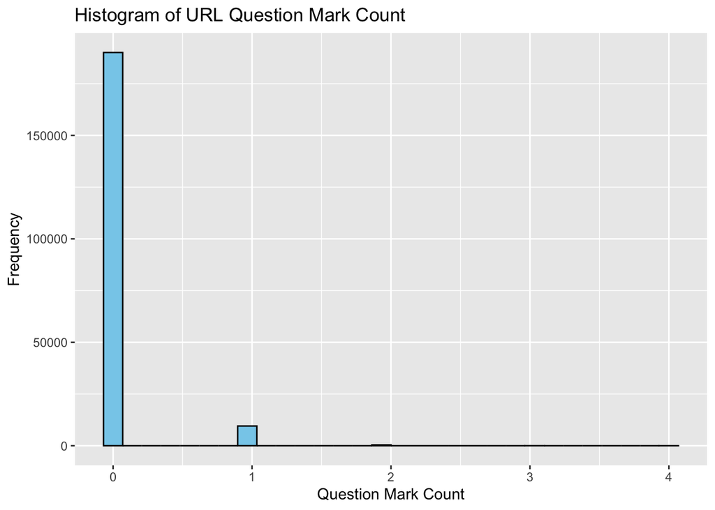

```r
# Plotting histogram using ggplot2
ggplot(numerical_columns, aes(x = url_count_ques)) +
  geom_histogram(bins = 30, fill = "skyblue", color = "black") +
  labs(title = "Histogram of URL Question Mark Count", x = "Question Mark Count", y = "Frequency")
```

#### Distribution of url_count_equal

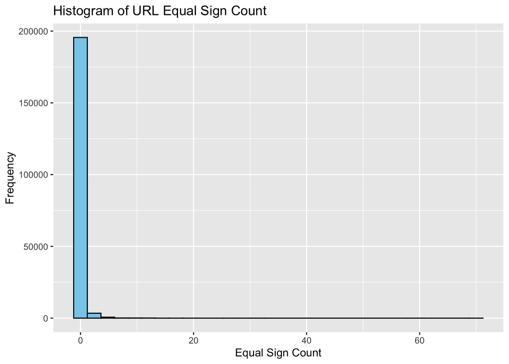

```r
# Plotting histogram using ggplot2
ggplot(numerical_columns, aes(x = url_count_equal)) +
  geom_histogram(bins = 30, fill = "skyblue", color = "black") +
  labs(title = "Histogram of URL Equal Sign Count", x = "Equal Sign Count", y = "Frequency")
```

#### Distribution of url_count_amp

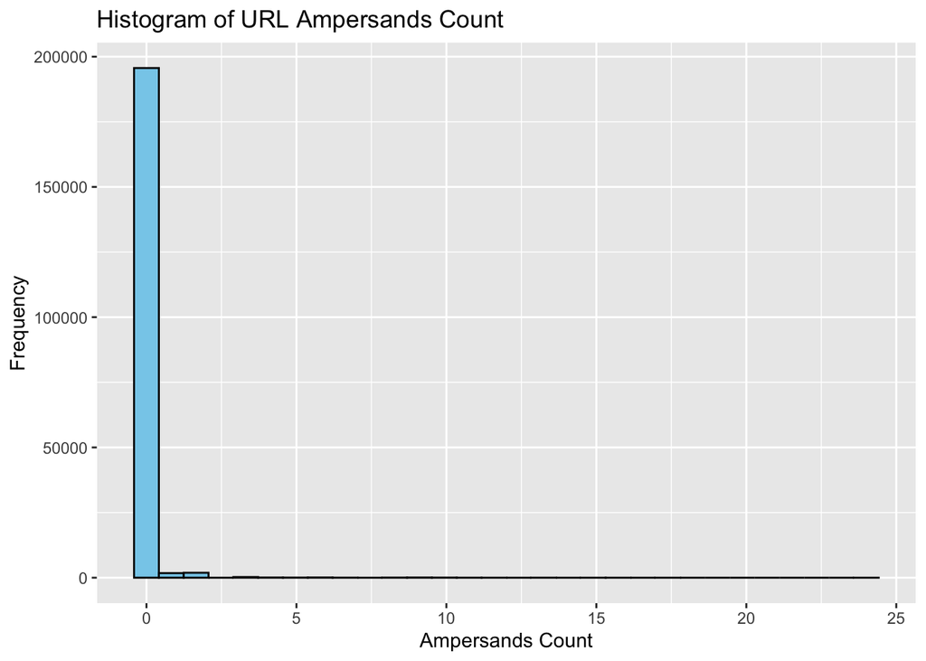

```r
# Plotting histogram using ggplot2
ggplot(numerical_columns, aes(x = url_count_amp)) +
  geom_histogram(bins = 30, fill = "skyblue", color = "black") +
  labs(title = "Histogram of URL Ampersands Count", x = "Ampersands Count", y = "Frequency")
```

#### Distribution of url_count_letter

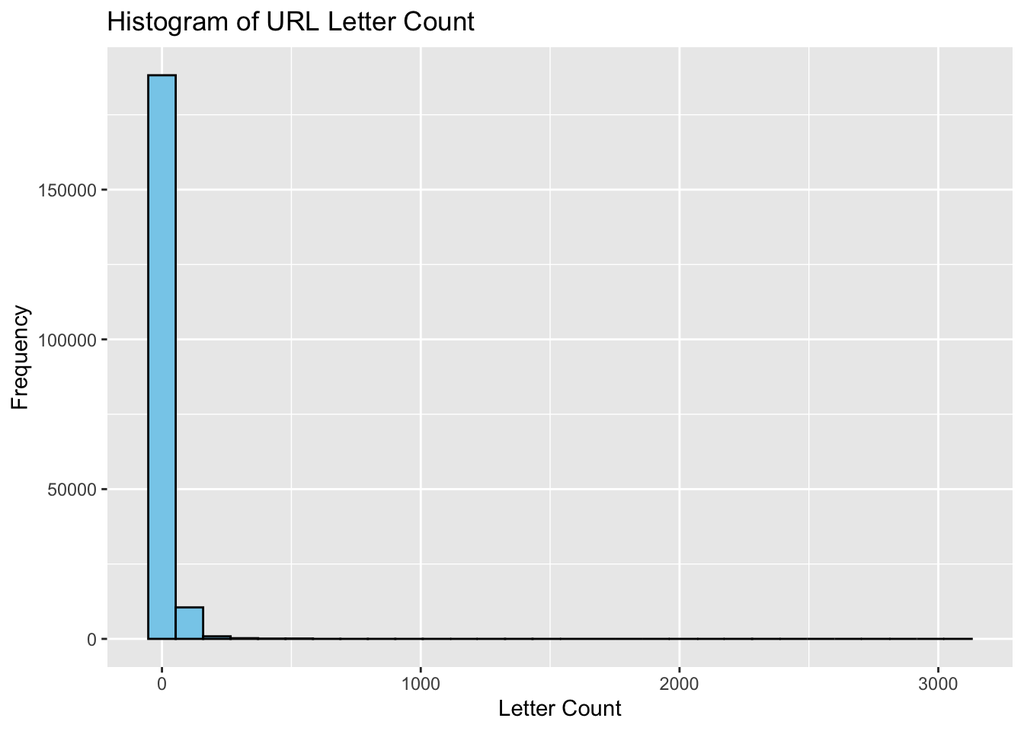

```r
# Plotting histogram using ggplot2
ggplot(numerical_columns, aes(x = url_count_letter)) +
  geom_histogram(bins = 30, fill = "skyblue", color = "black") +
  labs(title = "Histogram of URL Letter Count", x = "Letter Count", y = "Frequency")
```

#### Distribution of url_count_digit

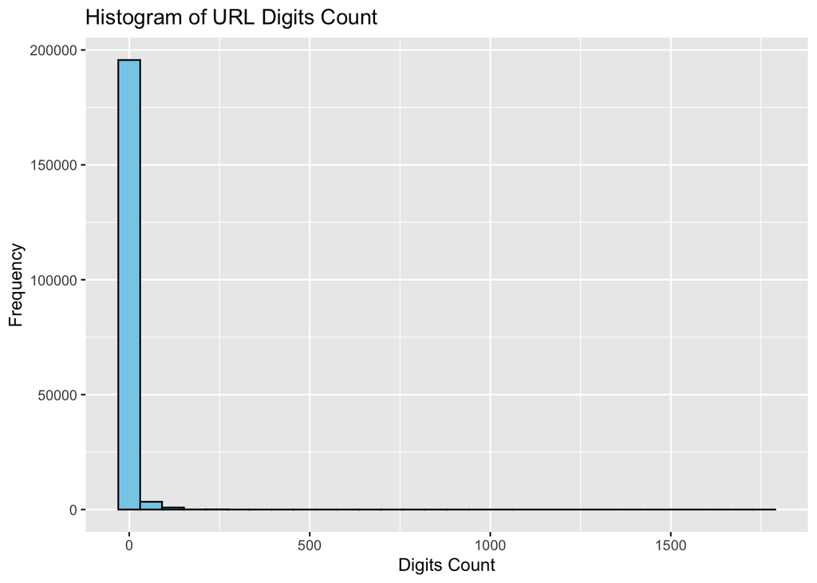

```r
# Plotting histogram using ggplot2
ggplot(numerical_columns, aes(x = url_count_digit)) +
  geom_histogram(bins = 30, fill = "skyblue", color = "black") +
  labs(title = "Histogram of URL Digits Count", x = "Digits Count", y = "Frequency")
```

#### Distribution of url_count_sensitive_financial_words

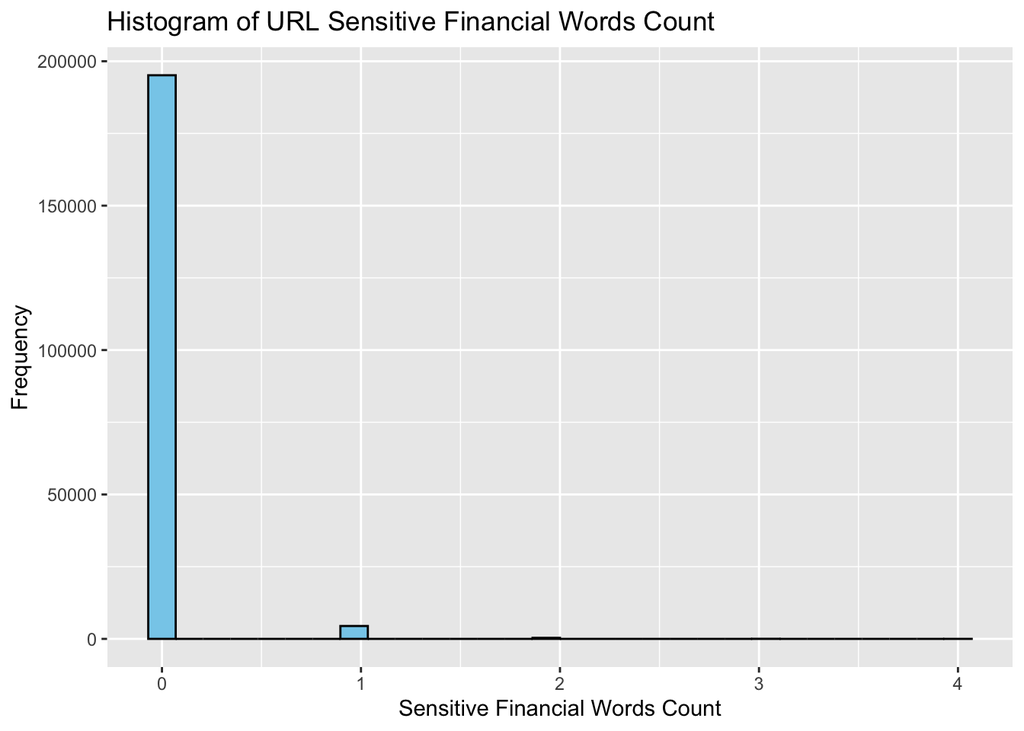

```r
# Plotting histogram using ggplot2
ggplot(numerical_columns, aes(x = url_count_sensitive_financial_words)) +
  geom_histogram(bins = 30, fill = "skyblue", color = "black") +
  labs(title = "Histogram of URL Sensitive Financial Words Count",
       x = "Sensitive Financial Words Count", y = "Frequency")
```

#### Distribution of url_count_sensitive_words

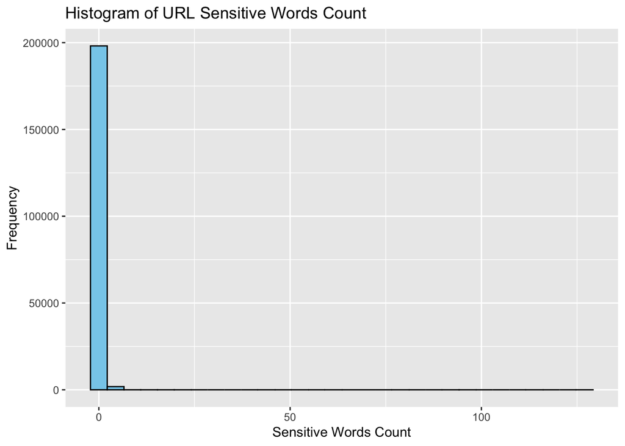

```r
# Plotting histogram using ggplot2
ggplot(numerical_columns, aes(x = url_count_sensitive_words)) +
  geom_histogram(bins = 30, fill = "skyblue", color = "black") +
  labs(title = "Histogram of URL Sensitive Words Count",
       x = "Sensitive Words Count", y = "Frequency")
```

#### Distribution of path_len

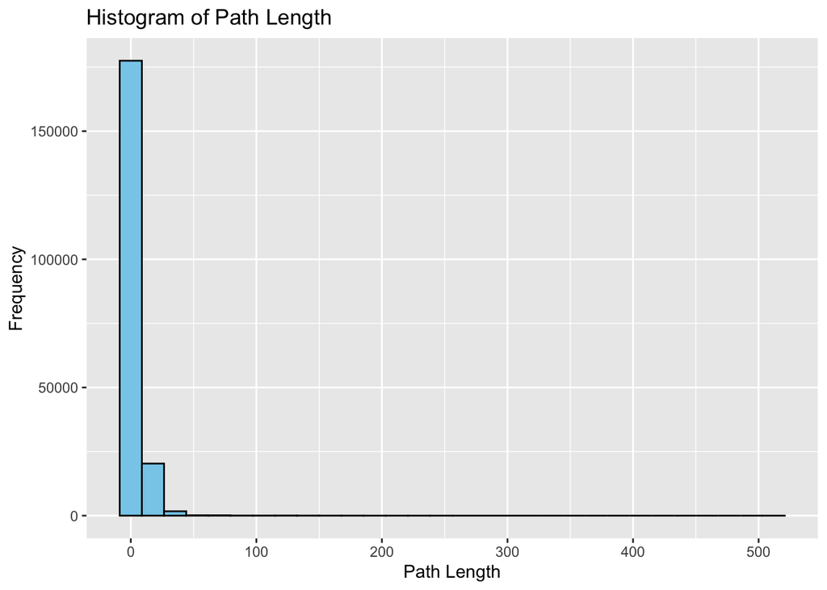

```r
# Plotting histogram using ggplot2
ggplot(numerical_columns, aes(x = path_len)) +
  geom_histogram(bins = 30, fill = "skyblue", color = "black") +
  labs(title = "Histogram of Path Length", x = "Path Length", y = "Frequency")
```

#### Distribution of query_len

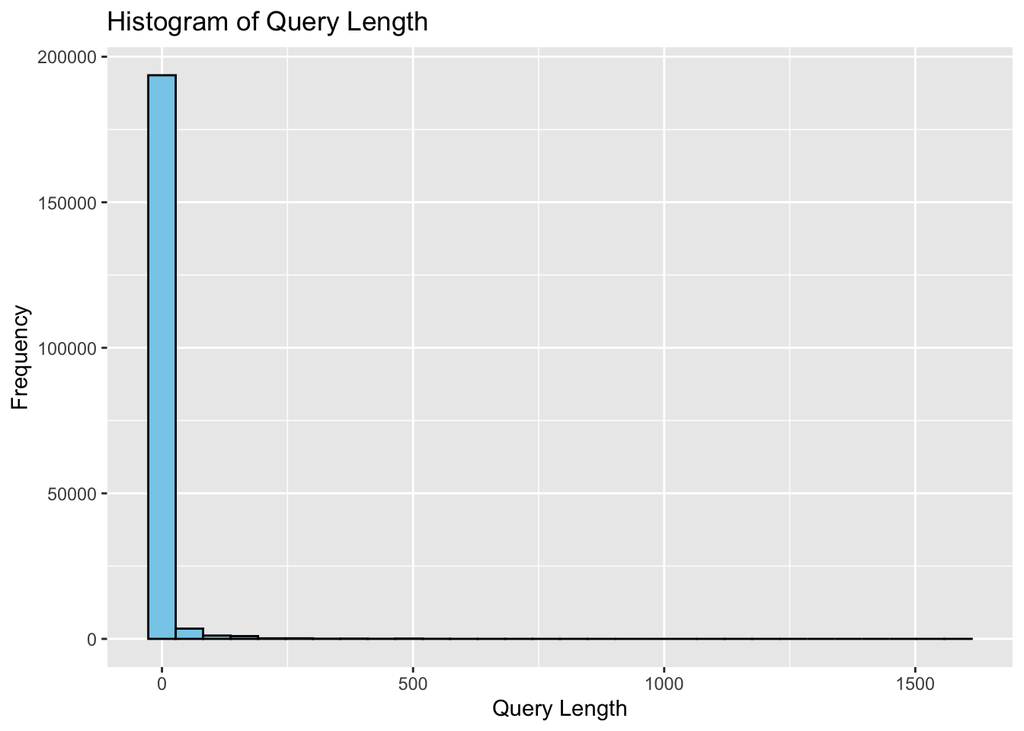

```r
# Plotting histogram using ggplot2
ggplot(numerical_columns, aes(x = query_len)) +
  geom_histogram(bins = 30, fill = "skyblue", color = "black") +
  labs(title = "Histogram of Query Length", x = "Query Length", y = "Frequency")
```

#### Distribution of query_count_components

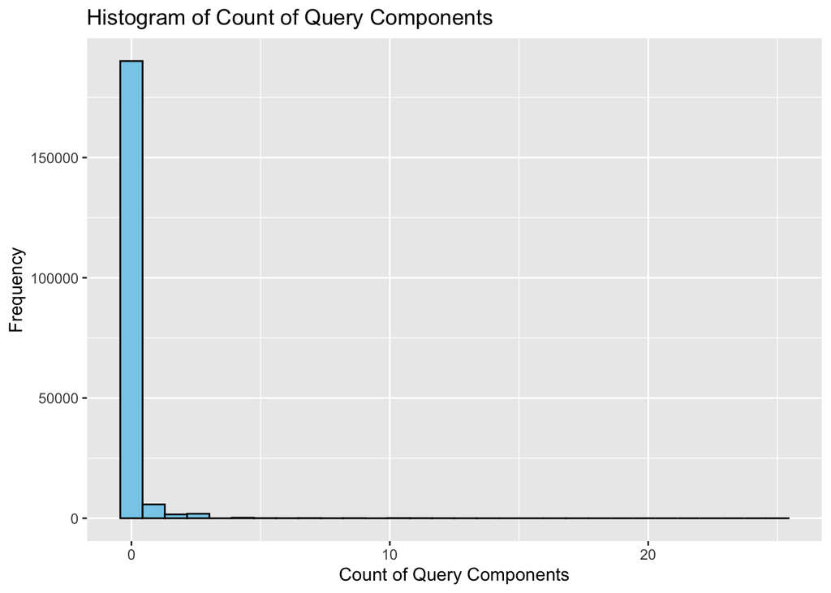

```r
# Plotting histogram using ggplot2
ggplot(numerical_columns, aes(x = query_count_components)) +
  geom_histogram(bins = 30, fill = "skyblue", color = "black") +
  labs(title = "Histogram of Count of Query Components",
       x = "Count of Query Components", y = "Frequency")
```

#### Distribution of primary domain length

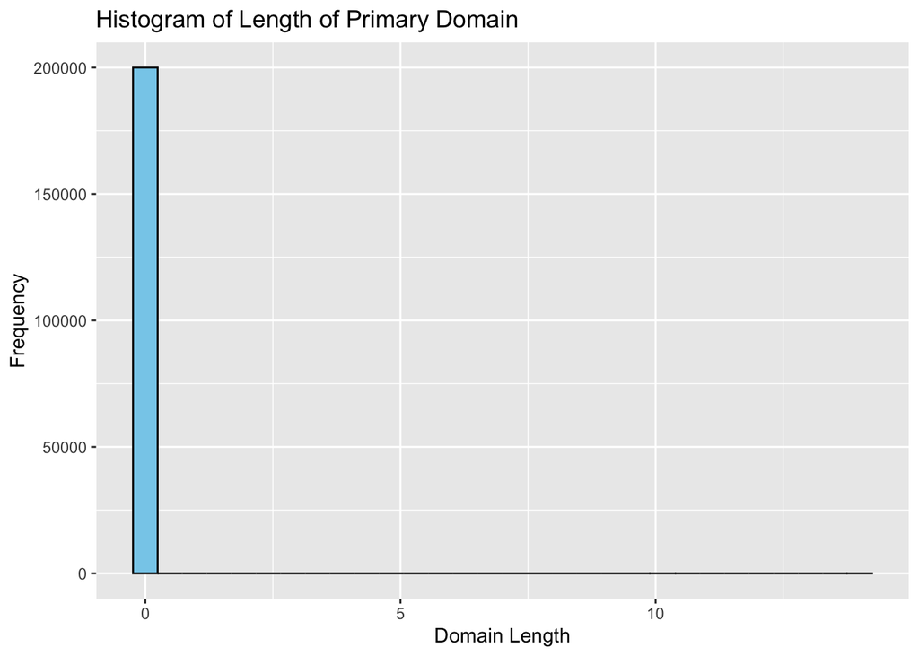

```r
# Plotting histogram using ggplot2
ggplot(numerical_columns, aes(x = pdomain_len)) +
  geom_histogram(bins = 30, fill = "skyblue", color = "black") +
  labs(title = "Histogram of Length of Primary Domain",
       x = "Domain Length", y = "Frequency")
```

#### Distribution of subdomain len

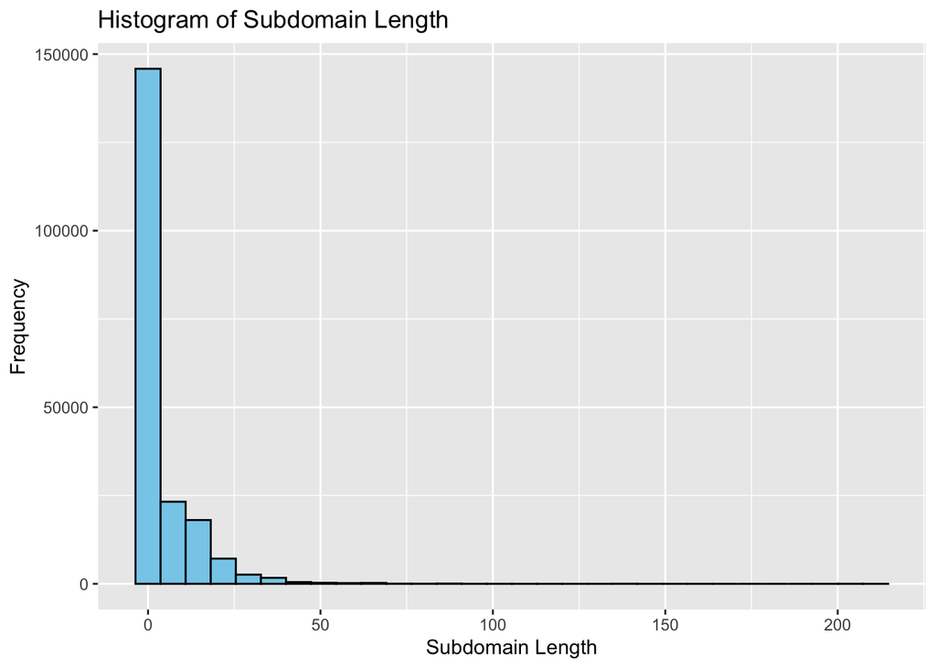

```r
# Plotting histogram using ggplot2
ggplot(numerical_columns, aes(x = subdomain_len)) +
  geom_histogram(bins = 30, fill = "skyblue", color = "black") +
  labs(title = "Histogram of Subdomain Length",
       x = "Subdomain Length", y = "Frequency")
```

#### Distribution of subdomain_count_dot

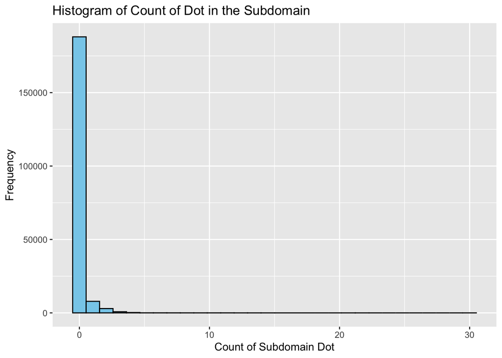

```r
# Plotting histogram using ggplot2
ggplot(numerical_columns, aes(x = subdomain_count_dot)) +
  geom_histogram(bins = 30, fill = "skyblue", color = "black") +
  labs(title = "Histogram of Count of Dot in the Subdomain",
       x = "Count of Subdomain Dot", y = "Frequency")
```

Other than URL entropy, all the variables are positively skewed with a clear sign of large outliers. These outliers could skew our analysis results and therefore, we will deal with them in the Data Preparation section.

### Treating Outliers

We defined a function for identifying and managing outliers within a dataset. The function takes three parameters: the dataset data, a vector specifying the columns to be processed columns, and a threshold determining the outlier deterction criteria, set to 3 standard deviations from the mean. Detected outliers are replaced with NA values, and a summary is printed for each column, indicating the number of outliers removed. Then all the missing valuas (NA) are omitted.

```r
# Removing outliers
remove_outliers <- function(data, columns, threshold = 3) {
  # Iterate over each specified column
  for (col in columns) {
    # Calculate mean and standard deviation
    mean_value <- mean(data[[col]], na.rm = TRUE)
    sd_value <- sd(data[[col]], na.rm = TRUE)

    # Identify outliers
    outliers <- data[data[[col]] > mean_value + threshold * sd_value |
                     data[[col]] < mean_value - threshold * sd_value, ]

    # Treat outliers (replace with NA)
    data[[col]][data[[col]] > mean_value + threshold * sd_value |
                data[[col]] < mean_value - threshold * sd_value ] <- NA

    # Print summary
    cat("Outliers removed for column:", col, "\n")
    cat("Number of outliers removed:", nrow(outliers), "\n\n")
  }

  return(data)

}

# Call the function
train_data_cleaned <- remove_outliers(train_data, names(numerical_columns), threshold = 3)
```

```
## Outliers removed for column: url_len
## Number of outliers removed: 3083
##
## Outliers removed for column: url_entropy
## Number of outliers removed: 561
##
## Outliers removed for column: url_count_dot
## Number of outliers removed: 2073
##
## Outliers removed for column: url_count_https
## Number of outliers removed: 700
##
## Outliers removed for column: url_count_http
## Number of outliers removed: 861
##
## Outliers removed for column: url_count_perc
## Number of outliers removed: 116
##
## Outliers removed for column: url_count_hyphen
## Number of outliers removed: 3354
##
## Outliers removed for column: url_count_www
## Number of outliers removed: 1743
##
## Outliers removed for column: url_count_hash
## Number of outliers removed: 399
##
## Outliers removed for column: url_count_semicolon
## Number of outliers removed: 268
##
## Outliers removed for column: url_count_underscore
## Number of outliers removed: 995
##
## Outliers removed for column: url_count_ques
## Number of outliers removed: 9926
##
## Outliers removed for column: url_count_equal
## Number of outliers removed: 3067
##
## Outliers removed for column: url_count_amp
```

[output cut: 16 more lines]

```
##
## Outliers removed for column: query_len
## Number of outliers removed: 2762
##
## Outliers removed for column: query_count_components
## Number of outliers removed: 4121
##
## Outliers removed for column: pdomain_len
## Number of outliers removed: 2
##
## Outliers removed for column: subdomain_len
## Number of outliers removed: 3567
##
## Outliers removed for column: subdomain_count_dot
## Number of outliers removed: 4172
```

```r
# Remove nulls
train_data_cleaned <- na.omit(train_data_cleaned)
```

### Relationship Between Our Target Variable, Label, and All Other Variables

#### Correlation Between Numerical Variables and Target Variable, Label

Then, we perform correlation analysis between numerical variables and a binary label in a dataset. We define a function named correlation_plot that calculates point-biserial correlation coefficients for each numerical variable with respect to the binary label. This function iterates over the numerical columns, computes the correlation coefficient using the biserial.cor function, and appends the results to the global dataframe correlation_data. Finally, the function generates a bar plot of correlations ordered from highest to lowest, providing insights into the strength and direction of association between each numerical variable and the binary label.

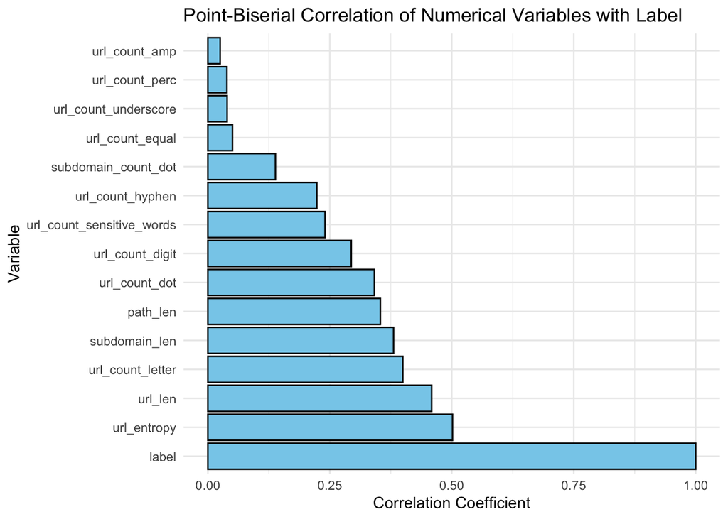

```r
# Select binary variables
binary_cols <- names(binary_df)

# Remove the label
binary_cols <- setdiff(binary_cols, "label")

# Initialize an empty dataframe to store correlation coefficients
correlation_data <- data.frame(variable = character(),
                               correlation = numeric(),
                               stringsAsFactors = FALSE)

correlation_plot <- function(data, label_column) {

  # Select numerical columns
  data2 <- select_if(data, is.numeric)

  # Remove the binary variables
  numerical_cols <- data2[, !(names(data2) %in% binary_cols)]

  # Iterate over numerical columns
  for (col in names(numerical_cols)) {

    # Calculate point-biserial correlation
    corr <- biserial.cor(data[[col]], as.numeric(data[[label_column]]),
                         use = c("all.obs"), level = 2)

    # Store correlation coefficient in the global dataframe
    correlation_data <<- bind_rows(correlation_data,
                                   data.frame(variable = col,
                                              correlation = corr))
  }

  # Plot correlation coefficients with bars ordered from max to min correlation
  ggplot(na.omit(correlation_data), aes(x = reorder(variable, -correlation), y = correlation)) +
    geom_bar(stat = "identity", fill = "skyblue", color ="black") +
    coord_flip() +
    labs(title = "Point-Biserial Correlation of Numerical Variables with Label",
         x = "Variable",
         y = "Correlation Coefficient") +
    theme_minimal()
}

# Calling the function
correlation_plot(train_data_cleaned, "label")
```

```r
# Showing the dataframe
print(correlation_data)
```

```
##                               variable correlation
## 1                              url_len  0.45878250
## 2                          url_entropy  0.50146422
## 3                        url_count_dot  0.34126717
## 4                      url_count_https         NaN
## 5                       url_count_http         NaN
## 6                       url_count_perc  0.03901660
## 7                     url_count_hyphen  0.22343556
## 8                        url_count_www         NaN
## 9                       url_count_hash         NaN
## 10                 url_count_semicolon         NaN
## 11                url_count_underscore  0.03944986
## 12                      url_count_ques         NaN
## 13                     url_count_equal  0.05039230
## 14                       url_count_amp  0.02513906
## 15                    url_count_letter  0.39964435
## 16                     url_count_digit  0.29400054
## 17 url_count_sensitive_financial_words         NaN
## 18           url_count_sensitive_words  0.24018686
## 19                            path_len  0.35356281
## 20                           query_len         NaN
## 21              query_count_components         NaN
## 22                         pdomain_len         NaN
## 23                       subdomain_len  0.38067851
## 24                 subdomain_count_dot  0.13849100
## 25                               label  1.00000000
```

The plot above visualizes the data in the data frame printed above. We can see that we have numerical columns that have medium strength correlation with our target variable which is label. Some of the columns had NaNs so we will not be moving forward with any column that had no correlation with our target variable.

It is important to note that all our variables are positively correlated to our target variable

URL entropy has the strongest correlation with our target variable label, followed by URL Length, URL letter count and sub domain length in that order.